# 2019 Grammy Twitter Analysis

Luis Noguera

2/14/2019

The 61st Grammy Award ceremony was celebrated the night of February 10th 2019. Some of the best artists in the industry gathered together in Los Angeles, California for the awards announcement. Some of the notable award winners were: Childish Gambino with four awards, Kacey Musgraves also with four, including album of the year for “Golden Hour”, Cardi B best rap album and Dua Lipa as best new artist. A ceremony dominated by women in most categories, remmarkable considering one year earlier the Recording Academy President Neil Portnow, said women neededed to “step up” if they wanted to see more female artists nominated at the annual ceremony.

After the winners have been announced, I decided to analyse the reactions of the ceremony in Twitter. Let’s see what the the users of this platform though about the annual ceremony.

Important aspects to consider in the analysis:

- 10,000 tweets including retweets have been dowloaded
- 5,000 with the hashtag #Grammys2019
- 5,000 tweets with the hashtag #GRAMMYs.
- Tweets downloaded are a random sample of tweets
- Location of the tweets is random
- Language of the tweets is only in English
- Tweets downloaded were posted between (Feb 10 2019 and Feb 11 2019)

# Frequent Words

This graph contains the most frequent words from the sample. At the beginning of the analysis I had no idea what “btw_twt”" was, I decided to look into it in Twitter and turns out that is a Korean Band Boy that was nominated and earned an award for “Best Recording Package”. From this sample, the Korean band was the most frequent token mentioned.

I found out they have two Twitter accounts, one in English and one in Korean, with 14.1 million and 18 million followers respectively. They are huge in this platform and stole many hearts during and after the ceremony in Twitter.

Feel free to check out their Twitter account here: https://twitter.com/bts_bighit

Curiously, the third most frequent token is “blackpink”, another South Korean band I did not know of. Apparently, the fans of these two South Korean bands are very active in twitter, at leats from these sample of 10,000 tweets.

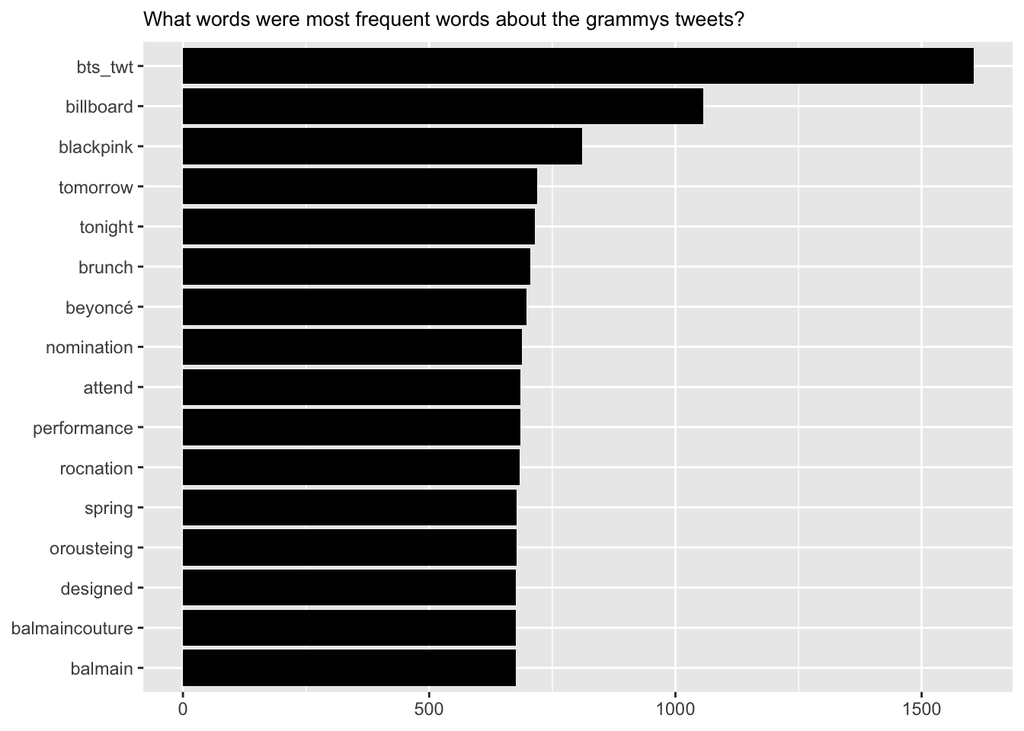

# Most Frequent Three-grams

```
## # A tibble: 6 x 4
##   word1          word2                word3              n
##   <chr>          <chr>                <chr>          <int>
## 1 balmain        beyoncé              wears            617
## 2 etnow          btsinamerica         finally          354
## 3 camila_cabello live                 performance      272
## 4 grammy         nominee              camila_cabello   272
## 5 nominee        camila_cabello       live             272
## 6 bts_bighit     bestrecordingpackage btsxgrammy       174
```

# Map of Most Frequent Three-grams

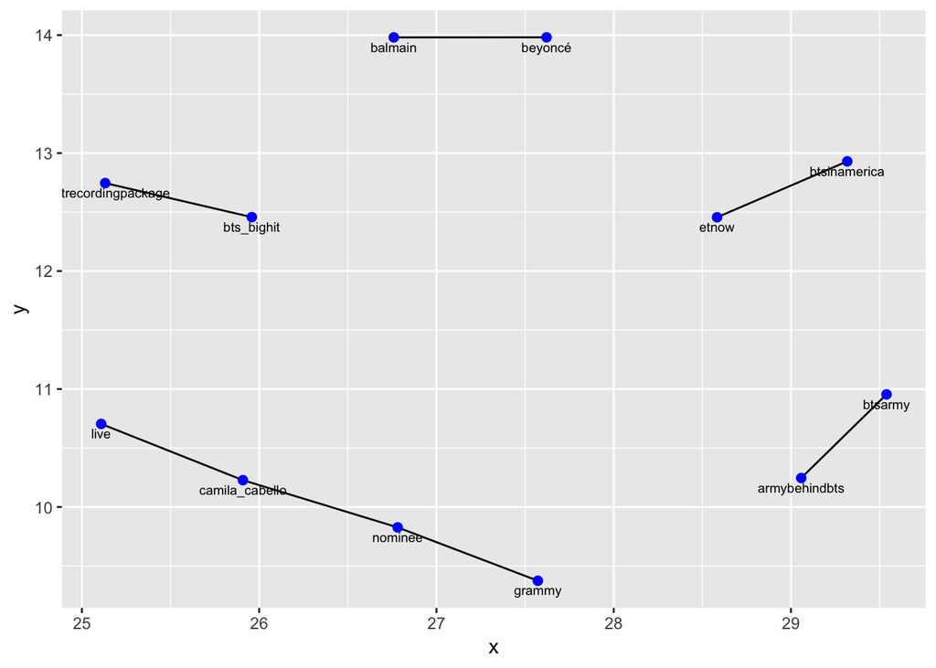

After checking the most frequent words, I decided to analyse the sequence of 3 words most frequently repeated. A sentence migh tell us more about the tweet than just a word.

Most frequent three-gram in my analysis is for Beyonce who wore a Balmain dress, not at the grammys ceremony but the day before, February 9th in the Roc Nation Pre-Grammy’s brunch. Good for her and the French clothing brand, a clear example of how this type of “partnerships” resonates among Twitter users. For those interested in fashion, you can take a look at the comments of Beyonce’s dress here: https://www.harpersbazaar.com/celebrity/latest/a26270704/beyonce-balmain-dress-jay-z-photos/

Lastly, the other 3 relationships in the map are for the previously mentioned band BTS, their fans “armybehindbts”, “btsinamerica” and their grammy award for Best Recording Package.

# Sentiment Analysis of the Grammys 2019

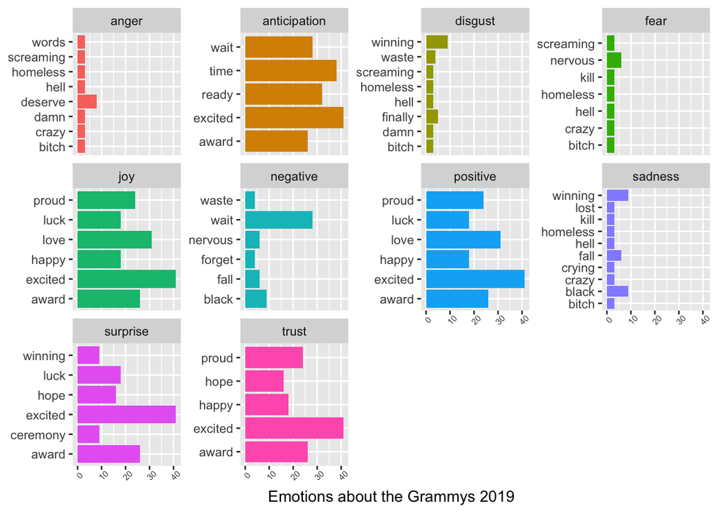

Finally, I wanted to try out the ‘nrc’ lexicon to check out the overall sentiment of the ceremony in Twitter. The results were very similar to what I was expecting to get, anticipation, joy, positive and trust feelings outweight by far the rest more negative ones included in the lexicon. The Academy put a nice show that excited viewers and users on Twitter one more year. Let’s see what the future holds for this prestigious ceremony and artists who take part on it.